# Atributos funcionais, razão de massa e funcionamento das florestas tropicais

Biodiversidade e funcionamento do ecossistema (BFE)

Lourens Poorter (slides originais) — versão reorganizada

Wageningen University & Research

7 de novembro de 2025

## Uma pergunta central

**O que, na biodiversidade de uma floresta tropical, controla seu funcionamento?**

- o **número** de espécies (riqueza)?
- a **variedade** de atributos funcionais (diversidade funcional)?
- os atributos das espécies **dominantes** (razão de massa)?
- simplesmente a **quantidade** de vegetação (biomassa)?

## Roteiro

1. **Conceitos:** atributos funcionais, biodiversidade funcional e as três hipóteses
2. **Teoria da razão de massa** e como medi-la (MPC)
3. **Evidências em florestas tropicais:** sucessão, florestas maduras, florestas secas, simulações
4. **Dominância:** por que poucas espécies fazem quase tudo
5. **Síntese:** o que sabemos e o que falta

# 1. Conceitos

## Por que atributos funcionais?

O número de espécies diz pouco sobre **o que as espécies fazem**.

Os **atributos funcionais** são características (morfológicas, fisiológicas, fenológicas) que influenciam o desempenho individual e, somados, o funcionamento do ecossistema.

- **Atributos de resposta:** como a espécie reage ao ambiente (luz, seca, perturbação)
- **Atributos de efeito:** como a espécie afeta processos (produtividade, decomposição, estoque de carbono)

**O que importa não é só quantas espécies existem, mas quais atributos elas têm e quanto pesam na comunidade.**

Díaz et al. (2007) PNAS

## Riqueza de espécies e processo ecossistêmico

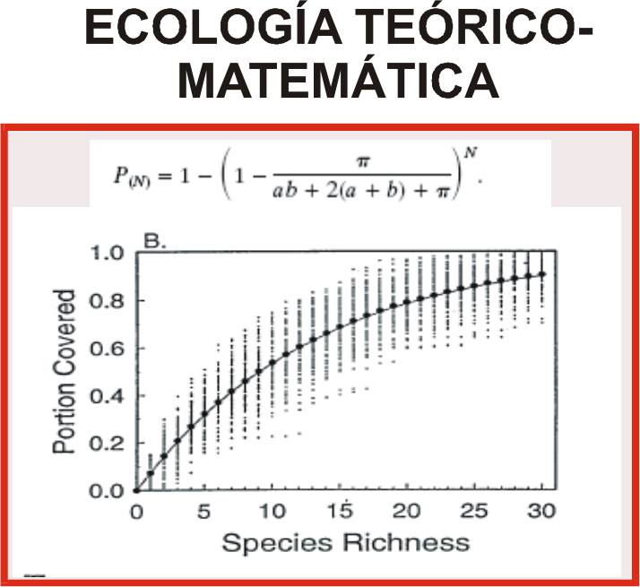

Processo ecossistêmico × riqueza de espécies. Nem todas as espécies são iguais, nem igualmente abundantes.

Slide: S. Díaz

## Biodiversidade funcional: média, amplitude e presença

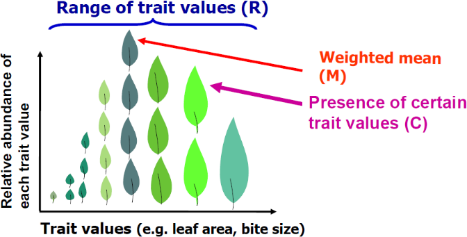

R: amplitude dos valores do atributo · M: média ponderada · C: presença de certos valores.

Slide: S. Díaz · Díaz et al. (2007) PNAS

## Três componentes da biodiversidade funcional

| Componente | Pergunta | Métrica típica |
| --- | --- | --- |
| **Valor / média** | Qual é o atributo típico (dominante)? | Média ponderada da comunidade (MPC) |
| **Amplitude / variedade** | Quão diferentes são as espécies? | Riqueza, equabilidade e divergência funcional (DF) |
| **Presença** | Existe um atributo particular? | Presença de um tipo funcional ou espécie-chave |

## Três hipóteses rivais para o funcionamento do ecossistema

**Biomassa**  
(quantidade de vegetação)

**Média ponderada dos atributos**  
(MPC)

**Diversidade funcional**  
(variedade de atributos)

→Sopa verde

→Razão de massa

→Complementaridade de nicho

Função do ecossistema

## O que cada hipótese prevê

| Hipótese | Mecanismo | Predição | Métrica |
| --- | --- | --- | --- |
| **Sopa verde** | Mais vegetação, mais processo | Função cresce com a biomassa | Biomassa inicial |
| **Razão de massa** | Os atributos das espécies **dominantes** determinam o processo | Função segue o valor médio do atributo | MPC |
| **Complementaridade de nicho** | Espécies diferentes usam recursos diferentes | Função cresce com a variedade de atributos | Riqueza, equabilidade e divergência funcional |

Garnier et al. (2004) Ecology · Lohbeck et al. (2015) Ecology · Finegan et al. (2015) J. Ecol.

# 2. Teoria da razão de massa

## A hipótese da razão de massa (*mass ratio*)

Em Grime (1998), as espécies de uma comunidade se dividem em:

- **Dominantes:** grandes, respondem pela maior parte da biomassa
- **Subordinadas:** menores, vivem em microhabitats criados pelas dominantes
- **Transientes:** pouco abundantes e de vida curta (muitas vezes juvenis de espécies vizinhas)

**Ideia central:** o controle imediato dos processos ecossistêmicos depende, em grande parte, dos **atributos das espécies dominantes** (a contribuição de cada espécie é proporcional à sua fração da biomassa), e pouco da riqueza de espécies subordinadas e transientes.

Grime (1998) Journal of Ecology 86: 902–910 · Garnier et al. (2004) Ecology 85: 2630–2637

## Como medir: a média ponderada da comunidade (MPC)

Para cada parcela, somam-se os valores do atributo de todas as espécies, ponderados pela sua abundância relativa:

**MPC = Σ (abundância relativa da espécie × valor do atributo da espécie)**

Em símbolos: MPC<sub>j</sub> = Σ<sub>i</sub> p<sub>ij</sub> · t<sub>i</sub>, onde p<sub>ij</sub> é a abundância relativa da espécie i na parcela j e t<sub>i</sub> é o valor do atributo.

- Dados: matriz **parcelas × espécies** (p<sub>ij</sub>) e matriz **espécies × atributos** (t<sub>i</sub>)
- **Área basal (ou cobertura)** acompanha de perto a biomassa e a área foliar total: tende a se relacionar mais fortemente com o PE que a abundância ou a presença/ausência
- Presença/ausência dá peso excessivo a espécies acidentais

## MPC e diversidade funcional em R

```r
library(FD)

# traits: espécies x atributos (AFE, TNF, densidade da madeira, Hmax...)
# abund : parcelas x espécies (área basal)
mpc <- functcomp(x = traits, a = abund)   # MPC por parcela

fd  <- dbFD(x = traits, a = abund)        # riqueza, equabilidade, divergência
```

## Dos atributos das espécies aos atributos da comunidade

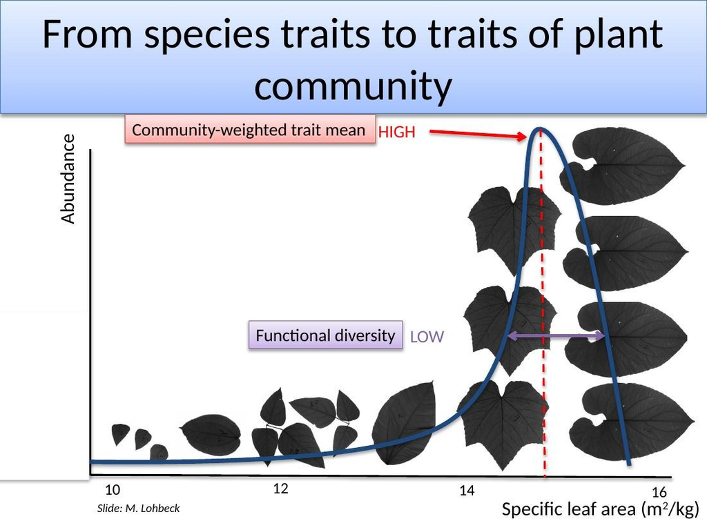

A mesma MPC pode vir com diversidade funcional baixa ou alta: MPC e DF descrevem coisas diferentes.

Slide: M. Lohbeck

## Quais atributos medir? Atributos foliares

| Atributo | Responde a | Efeito sobre o funcionamento |
| --- | --- | --- |
| Área foliar específica (AFE), teor de N e P foliar | Luz, calor | Produtividade, decomposição |
| Teor de matéria seca, espessura e dureza foliar | Sombra, herbivoria | Estoque de carbono, serapilheira |
| Deciduidade, composição foliar | Seca, calor | Serapilheira, produtividade |

## Quais atributos medir? Madeira, tamanho e sementes

| Atributo | Responde a | Efeito sobre o funcionamento |
| --- | --- | --- |
| Densidade da madeira | Sombra, seca | Estoque de carbono |
| Altura máxima (Hmax) | Luz | Biomassa e estoque de carbono |
| Volume da semente, dispersão biótica | Sombra, conectividade | Fonte de alimento |

Nas florestas tropicais, grande parte da variação se organiza em um eixo **rápido ↔︎ lento** (aquisitivo ↔︎ conservativo).

Díaz et al. (2007) PNAS · Finegan et al. (2015) J. Ecol.

## Ressalvas sobre os índices de diversidade funcional

- Os processos são determinados por **todos** os atributos? → o índice de DF resume bem
- Por um **subconjunto** ou por **um só** atributo? → o índice de DF esconde o padrão
- Alternativa simples: descrever cada atributo por **MPC, coeficiente de variação (CV) e curtose (K)**

**VMV: Vago MultiVariado: você não sabe o que está olhando!**

Carreño-Rocabado et al. (2015) Ecological Applications

## Descrever cada atributo: MPC, CV e curtose

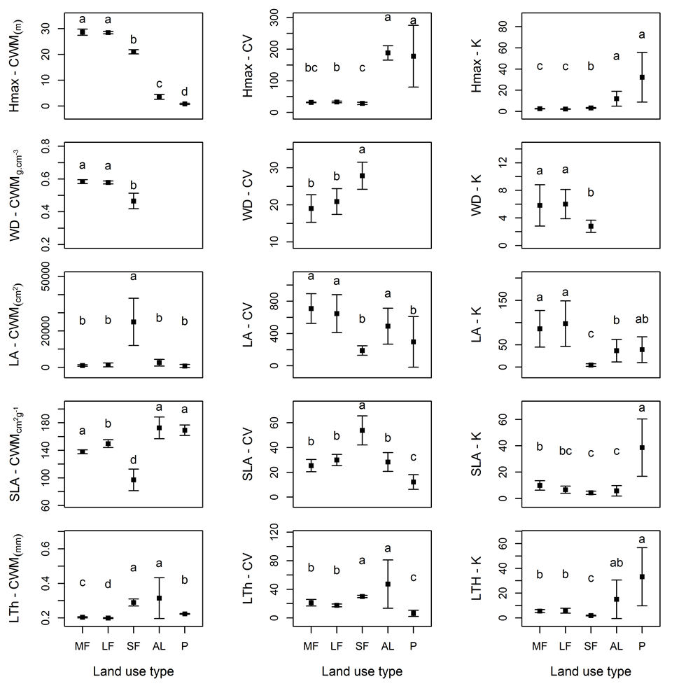

Carreño-Rocabado et al. (2015) Ecological Applications

# 3. Evidências nas florestas tropicais

## Sucessão secundária (México): a biomassa manda

Cronosequência após agricultura itinerante em floresta úmida. Processos: produtividade de biomassa e de serapilheira, decomposição. MEE com as três hipóteses.

- A **biomassa** foi o principal fator de **todos** os processos estudados
- A **MPC da AFE** afetou positivamente a produtividade de biomassa; a **MPC da matéria seca foliar** afetou negativamente a decomposição potencial
- A **divergência funcional** afetou positivamente a decomposição potencial
- MPC e diversidade funcional tiveram papel **secundário**: o forte acúmulo de biomassa ofusca efeitos mais sutis

**Quantidade de vegetação > qualidade da vegetação** (sopa verde).

Lohbeck, Poorter, Martínez-Ramos, Bongers (2015) Ecology 96: 1242–1252

## Na sucessão, a produtividade cresce com a biomassa

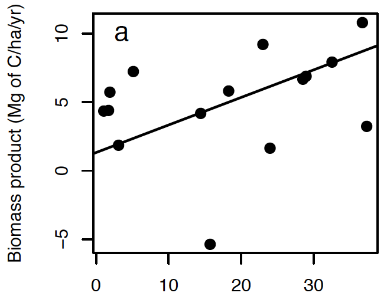

Produção de biomassa (Mg C/ha/ano) × biomassa (Mg C/ha).

Lohbeck, Poorter, Martínez-Ramos, Bongers (2015) Ecology

## Florestas maduras: os sítios diferem em seus atributos

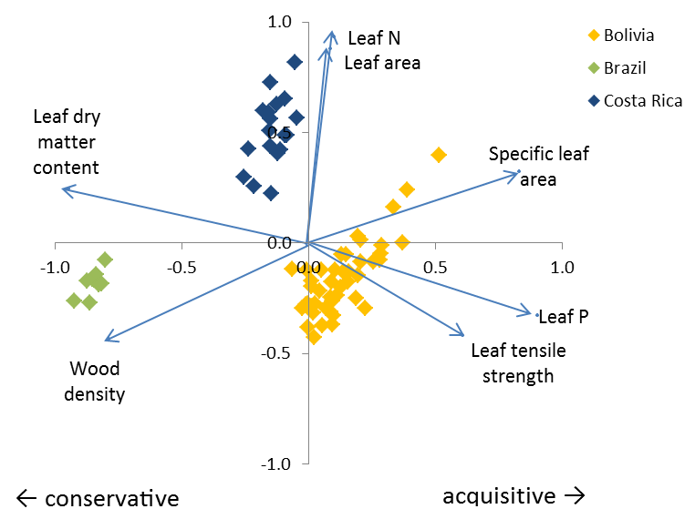

Eixo conservativo ↔︎ aquisitivo separa Bolívia, Brasil e Costa Rica (ACP da MPC de atributos).

Finegan, Peña-Claros, Oliveira, …, Poorter (2015) Journal of Ecology

## Florestas maduras: razão de massa com forte suporte

Biomassa aérea inicial (BAS) e incrementos de biomassa (árvores ≥ 10 cm de DAP) relacionados à MPC de 8 atributos e a quatro índices de DF.

- **Razão de massa: forte suporte.** A MPC da **altura máxima (Hmax)** foi o melhor preditor da BAS; atributos foliares, sobretudo a **AFE**, predisseram os incrementos
- **Complementaridade de nicho: sem suporte** (DF sem relação com os incrementos)
- **Sopa verde:** apoiada só para o incremento dos recrutas
- Povoamentos “rápidos” (AFE e TNF altos): crescimento rápido, mas rotatividade rápida e menor estoque

Finegan, Peña-Claros, Oliveira, …, Poorter (2015) Journal of Ecology

## Florestas secas: o modelo de biomassa

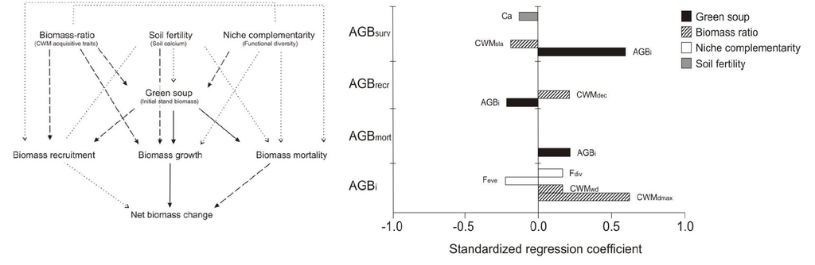

Hipóteses testadas por MEE (razão de massa, fertilidade do solo, complementaridade de nicho → sopa verde → recrutamento, crescimento e mortalidade → variação líquida de biomassa) e coeficientes padronizados. Rótulos na figura em inglês.

Prado-Junior, Schiavini, Vale, van der Sande, Lohbeck, Poorter (2016) Journal of Ecology

## Florestas secas: espécies conservativas dominam

200 parcelas permanentes em 8 florestas secas do Brasil, monitoradas por 5 anos.

- A **biomassa inicial** foi o melhor preditor de crescimento, mortalidade e recrutamento (sopa verde)
- Povoamentos de espécies **conservativas** (AFE baixa, densidade da madeira alta) tiveram **mais** crescimento e estoque: “lentos” nos atributos, “rápidos” na produtividade, ao contrário das florestas úmidas
- **Sem suporte** à complementaridade de nicho: **menor** diversidade funcional se associou a mais biomassa

Prado-Junior, Schiavini, Vale, van der Sande, Lohbeck, Poorter (2016) Journal of Ecology 104: 817–827

## Escala neotropical: diversidade, atributos e clima

**Poorter et al. (2017):** 26 sítios, 201 parcelas de 1 ha, > 92.000 árvores.

- Atributos da vegetação (riqueza, MPC, área basal) se relacionaram com biomassa e dinâmica mais vezes que o ambiente (67% vs. 33% das relações)
- **Disponibilidade de água:** o fator ambiental mais forte (crescimento e estoque)
- **Riqueza rarefeita:** relação positiva com estoques e dinâmica, mas **não** com a produtividade líquida
- **MPC:** bons preditores de estoques e dinâmica

**Poorter et al. (2015):** 59 sítios, ~2.050 parcelas, ~144.000 árvores. A riqueza de árvores tem efeito positivo e independente sobre a BAS, interpretado como uso complementar de recursos.

Poorter et al. (2015) Global Ecol. Biogeogr. · Poorter et al. (2017) Global Ecol. Biogeogr. 26: 1423–1434

## Recrutamento, crescimento e mortalidade

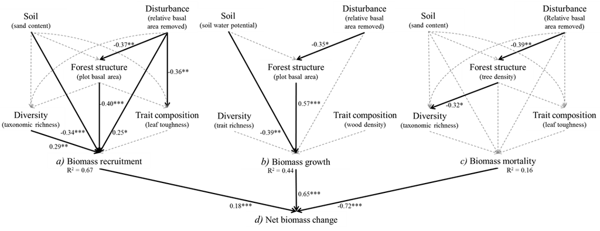

MEE de van der Sande et al. (dos slides originais): efeitos de solo, perturbação, estrutura, diversidade e atributos sobre recrutamento, crescimento e mortalidade.

van der Sande et al. (slides originais)

## Experimento virtual: o tempo desde a perturbação importa

Modelo individual de crescimento de floresta tropical, em simulações de longo prazo.

- Variou-se o **número de espécies** e de **grupos funcionais**, em vários níveis de perturbação
- Os efeitos da biodiversidade foram divididos em **complementaridade** e **seleção** ao longo do tempo
- A **diversidade funcional melhorou a resiliência** após a perturbação

**Complementaridade** domina logo após a perturbação; a **seleção** ganha peso quando espécies competitivas passam a dominar, e esse efeito é mais forte com perturbação intensa.

Schmitt, Maréchaux, Chave, Fischer, Piponiot-Laroche, Traissac, Hérault (2020) Journal of Ecology 108: 831–843

## Complementaridade primeiro, seleção depois

**Perturbação**

→

**Logo após:**  
complementaridade domina

→

**Com o tempo:**  
espécies competitivas dominam

→

**Depois:**  
seleção ganha peso

A seleção (dominantes competitivas) se aproxima, conceitualmente, da **razão de massa**. O **tempo desde a última perturbação** é chave para interpretar relações BFE.

Schmitt et al. (2020) Journal of Ecology 108: 831–843

## Placar das hipóteses em florestas tropicais

| Estudo | Sopa verde | Razão de massa (MPC) | Complementaridade |
| --- | --- | --- | --- |
| Lohbeck et al. 2015 (sucessão) | **Principal fator** | Secundária | Secundária |
| Finegan et al. 2015 (maduras) | Só recrutas | **Forte** (Hmax, AFE) | Sem suporte |
| Prado-Junior et al. 2016 (secas) | **Forte** | Conservativas dominam | Sem suporte |
| Poorter et al. 2015, 2017 (Neotrópico) | — | MPC bons preditores | **Riqueza** ↑ estoques |
| Schmitt et al. 2020 (simulação) | — | Seleção ganha peso com o tempo | **Domina** logo após a perturbação |

**Biomassa e razão de massa** explicam mais que a **diversidade funcional**; a **riqueza** pode ajudar o estoque de carbono (mecanismo debatido).

# 4. Dominância

## Por que a razão de massa funciona nos trópicos?

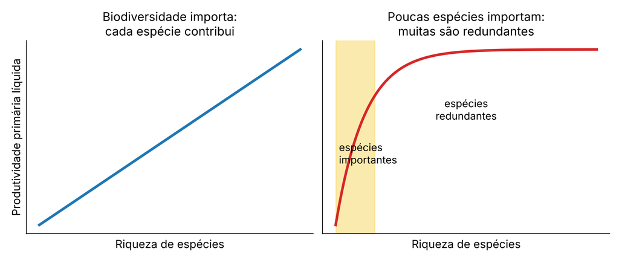

- **A dominância é a regra:** na Amazônia, ~1,4% das espécies compõem 50% das árvores (ter Steege et al. 2013)
- Poucas espécies concentram a biomassa e a produtividade; muitas são “redundantes” para o processo
- Se poucas espécies dominam, a **MPC** acompanha os atributos dessas poucas

ter Steege et al. (2013) Science · Lohbeck (2014) tese de doutorado, WUR

## Poucas espécies, muita função

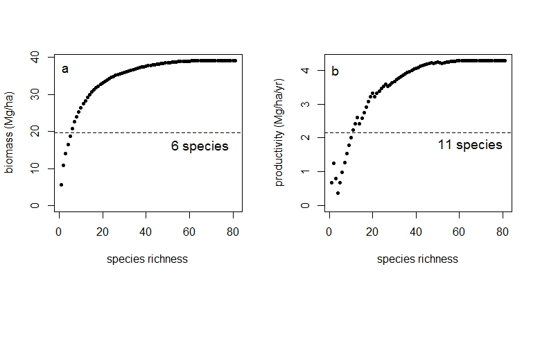

Biomassa e produtividade acumuladas × riqueza de espécies, com a linha de 50%: 6 espécies (biomassa) e 11 espécies (produtividade).

Madelon Lohbeck (2014) tese de doutorado, WUR

## Quantas espécies fazem 50% de cada função?

|  | Biomassa | Produção | Serapilheira | Decomposição (madeira) | Decomposição (folhas) |
| --- | --- | --- | --- | --- | --- |
| Nº de espécies para 50% da função | 6 | 11 | 6 | 2 | 5 |

Espécies mais importantes: *Trichospermum*, *Schizolobium*, *Cordia*, *Luehea*, *Vernonia*.

Madelon Lohbeck (2014) tese de doutorado, WUR

## Simulação 1: mantém a dominância, aleatoriza a identidade

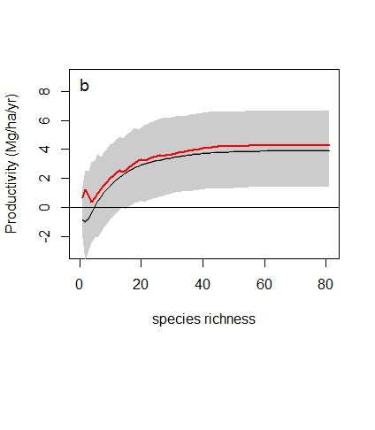

- A forma da curva **não muda**
- → A forma da curva vem da **estrutura de dominância**
- A variação em torno da curva vem da identidade das espécies

Madelon Lohbeck (2014) tese de doutorado, WUR

## Simulação 2: dominância igual, aleatoriza a identidade

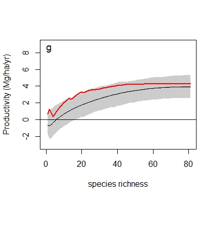

- A curva fica **mais linear**
- → A biodiversidade importa mais quando as abundâncias são **equilibradas**

Madelon Lohbeck (2014) tese de doutorado, WUR

## Quão universal é isso?

[figure not shown]

**1% das espécies de árvores** respondem por 50% do armazenamento e do sequestro de carbono na Amazônia.

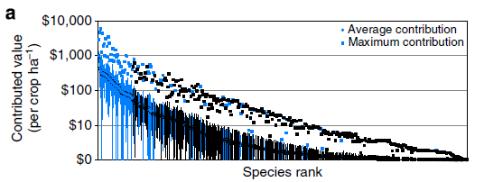

**2% das espécies de abelhas** respondem por 80% das visitas a flores de cultivos.

## O efeito seguro (*insurance*): simulações com MDGV

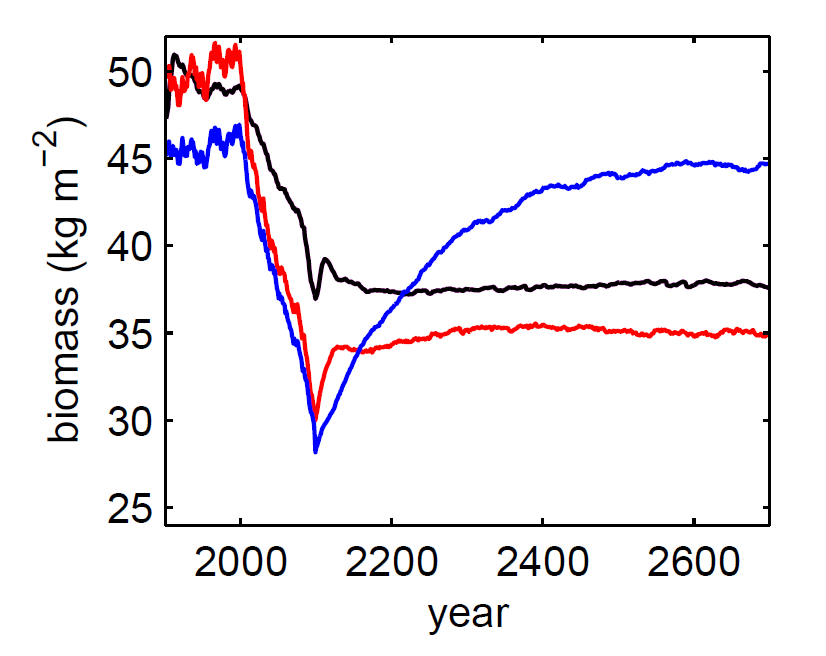

Biomassa (kg m⁻²) ao longo do tempo: MDGV de atributos com contínuo de grupos funcionais × MDGV normal com 2 grupos.

Sakschewski et al. (2016) Nature Climate Change 6: 1032–1036

## Do conjunto de dados ao modelo

Os modelos dinâmicos globais de vegetação (MDGV) usam **~5 tipos funcionais** para centenas de milhares de espécies.

Simulações que permitem **diversidade contínua de atributos** mostram que a diversidade funcional pode ajudar a floresta amazônica a **se ajustar a novas condições climáticas** (substituição de espécies úmidas por mais tolerantes à seca).

A razão de massa explica o **presente**; a diversidade pode importar para a **resiliência futura**.

Sakschewski et al. (2016) Nature Climate Change 6: 1032–1036

# 5. Síntese

## Como estudar: abordagem em cinco etapas

1. Defina o **processo (PE)** e o **serviço ecossistêmico (SE)** de interesse
2. Defina os **atributos de efeito** relevantes (exige compreensão mecanística)
3. **Meça** os atributos: por indivíduo? por espécie? Um indivíduo por espécie por parcela é razoável; o banco de dados descreve bem a MPC, mas mal a variação
4. **Calcule** a MPC (ponderar por área basal) e a DF (com CV e K como alternativas)
5. **Relacione** à função com MEE, **separando biomassa, MPC e DF**

Díaz et al. (2007) PNAS · Baraloto et al. (2010) Functional Ecology

## Mensagens-chave

- **Razão de massa:** nas florestas tropicais, os atributos das espécies **dominantes** (MPC) explicam produtividade e estoque melhor que a variedade de atributos
- **Biomassa primeiro:** a quantidade de vegetação costuma ofuscar efeitos da qualidade; **modele-a explicitamente**
- **Rápido ou lento depende do bioma:** em florestas úmidas, AFE alta → mais crescimento; em florestas secas, espécies conservativas sustentam a produtividade
- **Riqueza e carbono:** há efeito positivo da riqueza no estoque em escala neotropical, ainda sem mecanismo fechado
- **Tempo desde a perturbação:** a complementaridade domina logo após o distúrbio e a seleção, depois (Schmitt et al. 2020)
- **Biodiversidade importa:** para outros serviços (polinização, estabilidade) e para a resiliência a secas futuras

## Lacunas e próximos passos

- Combinar **simulações** e dados de campo para separar complementaridade e seleção ao longo da sucessão
- Testar **outros processos** além da produtividade de biomassa (decomposição, estabilidade, polinização)
- Medir a **variação intraespecífica** dos atributos, e não só médias de espécies
- Comparar métricas de DF **univariadas** com índices multivariados
- Integrar **diversidade e dominância** em modelos de vegetação

## Referências (1/3)

- Baraloto et al. (2010) Functional trait variation and sampling strategies in species-rich plant communities. *Functional Ecology* 24: 208–216.
- Carreño-Rocabado et al. (2015) *Ecological Applications*.
- Díaz, Lavorel, de Bello, Quétier, Grigulis, Robson (2007) Incorporating plant functional diversity effects in ecosystem service assessments. *PNAS*.
- Finegan, Peña-Claros, Oliveira, …, Poorter (2015) Does functional trait diversity predict aboveground biomass and productivity of tropical forests? Testing three alternative hypotheses. *Journal of Ecology*.
- Garnier et al. (2004) Plant functional markers capture ecosystem properties during secondary succession. *Ecology* 85: 2630–2637.

## Referências (2/3)

- Grime (1998) Benefits of plant diversity to ecosystems: immediate, filter and founder effects. *Journal of Ecology* 86: 902–910.
- Lohbeck, Poorter, Martínez-Ramos, Bongers (2015) Biomass is the main driver of changes in ecosystem process rates during tropical forest succession. *Ecology* 96: 1242–1252.
- Poorter et al. (2015) Diversity enhances carbon storage in tropical forests. *Global Ecology and Biogeography*.
- Poorter et al. (2017) Biodiversity and climate determine the functioning of Neotropical forests. *Global Ecology and Biogeography* 26: 1423–1434.
- Prado-Junior, Schiavini, Vale, van der Sande, Lohbeck, Poorter (2016) Conservative species drive biomass productivity in tropical dry forests. *Journal of Ecology* 104: 817–827.

## Referências (3/3)

- Sakschewski et al. (2016) Resilience of Amazon forests emerges from plant trait diversity. *Nature Climate Change* 6: 1032–1036.
- Schmitt, Maréchaux, Chave, Fischer, Piponiot-Laroche, Traissac, Hérault (2020) Functional diversity improves tropical forest resilience: Insights from a long-term virtual experiment. *Journal of Ecology* 108: 831–843.
- ter Steege et al. (2013) Hyperdominance in the Amazonian tree flora. *Science*.
- van der Sande et al. (2017) Abiotic and biotic drivers of biomass change in a Neotropical forest. *(conferir se é a versão publicada do trabalho “submetido” nos slides originais)*